# Exploring Salary Information from *Ask a Manager’s* 2021 Survey

# Data Cleaning

Before we begin answering any research questions, we need to perform some extensive cleaning on the dataset.

Most of the variable names in this dataset list out the entire question that was asked, making them long and unnecessary. We are going to use the `clean_names()` function from the `janitor` package to convert the names to `snake_case` format. Then, we are going to rename all of the columns to make them more compact and concise. The last few columns on the right side of the dataset are blank and unnecessary so we will also delete them.

```r
salary_clean_names <- salary %>%
  select(-(X:X.5)) %>%
  janitor::clean_names() %>%
  rename(age = how_old_are_you,
         industry = what_industry_do_you_work_in,
         job_title_context = if_your_job_title_needs_additional_context_please_clarify_here,
         extrapolated_annual_salary_unitless = what_is_your_annual_salary_you_ll_indicate_the_currency_in_a_later_question_if_you_are_part_time_or_hourly_please_enter_an_annualized_equivalent_what_you_would_earn_if_you_worked_the_job_40_hours_a_week_52_weeks_a_year,
         compensation = how_much_additional_monetary_compensation_do_you_get_if_any_for_example_bonuses_or_overtime_in_an_average_year_please_only_include_monetary_compensation_here_not_the_value_of_benefits,
         currency = please_indicate_the_currency,
         other_currency = if_other_please_indicate_the_currency_here,
         income_context = if_your_income_needs_additional_context_please_provide_it_here,
         country = what_country_do_you_work_in,
         us_state = if_you_re_in_the_u_s_what_state_do_you_work_in,
         city = what_city_do_you_work_in,
         overall_exp = how_many_years_of_professional_work_experience_do_you_have_overall,
         field_exp = how_many_years_of_professional_work_experience_do_you_have_in_your_field,
         education = what_is_your_highest_level_of_education_completed,
         gender = what_is_your_gender,
         race = what_is_your_race_choose_all_that_apply)

head(salary_clean_names)
```

```
##            timestamp   age                      industry
## 1 4/27/2021 11:02:10 25-34  Education (Higher Education)
## 2 4/27/2021 11:02:22 25-34             Computing or Tech
## 3 4/27/2021 11:02:38 25-34 Accounting, Banking & Finance
## 4 4/27/2021 11:02:41 25-34                    Nonprofits
## 5 4/27/2021 11:02:42 25-34 Accounting, Banking & Finance
## 6 4/27/2021 11:02:46 25-34  Education (Higher Education)
##                                  job_title job_title_context
## 1       Research and Instruction Librarian
## 2 Change & Internal Communications Manager
## 3                     Marketing Specialist
## 4                          Program Manager
## 5                       Accounting Manager
## 6           Scholarly Publishing Librarian
##   extrapolated_annual_salary_unitless compensation currency other_currency
```

[output cut: 20 more lines]

We will also convert all of the column names and individual values to lowercase letters.

```r
# Everything lowercase
for (n in colnames(salary_clean_names)){
  salary_clean_names[[n]] <- str_to_lower(salary_clean_names[[n]])}
```

We are going to convert some of the categorical variables into factors to make them easier to work with when we answer our research questions.

```r
# Change variable data type
salary_clean_dtype <- salary_clean_names %>%
  mutate(timestamp = mdy_hms(timestamp),
         age = factor(age),
         overall_exp = factor(overall_exp),
         field_exp = factor(field_exp),
         currency = factor(currency),
         education = factor(education),
         gender = factor(gender))
head(salary_clean_dtype)
```

```
##             timestamp   age                      industry
## 1 2021-04-27 11:02:10 25-34  education (higher education)
## 2 2021-04-27 11:02:22 25-34             computing or tech
## 3 2021-04-27 11:02:38 25-34 accounting, banking & finance
## 4 2021-04-27 11:02:41 25-34                    nonprofits
## 5 2021-04-27 11:02:42 25-34 accounting, banking & finance
## 6 2021-04-27 11:02:46 25-34  education (higher education)
##                                  job_title job_title_context
## 1       research and instruction librarian
## 2 change & internal communications manager
## 3                     marketing specialist
## 4                          program manager
## 5                       accounting manager
## 6           scholarly publishing librarian
##   extrapolated_annual_salary_unitless compensation currency other_currency
```

[output cut: 20 more lines]

The entries for the question asking about the respondents’ annual income contain commas to separate the thousands place from the hundreds place, making them character strings instead of numeric integers. We are going to eliminate those commas and convert the values to doubles, so they can be viewed as and dealt with as numbers.

```r
# Get rid of thousands separators (",")
salary_clean_dtype$extrapolated_annual_salary_unitless <- salary_clean_dtype$extrapolated_annual_salary_unitless %>%
  str_replace_all(",", "") %>%
  as.double()
```

Most of the respondents are from the United States, but there are some people who are from other countries such as Canada and the United Kingdom. We are going to filter out those individuals, leaving only the American respondents. The question asking about the individuals’ country of residence appears to be a short answer questions because the answers include different variations of the United States. To make everything consistent, we are going to recode all of these variations to “USA”. After doing so, all of the data that is left pertains to the USA, meaning that we no longer need the country and currency information. For that matter, for the rest of the analysis, we only require salary information, state information, education information and gender information - meaning that we can drop everything else and just keep `extrapolated_annual_salary_unitless`, `us_state`, `education`, and `gender`.

```r
#Recode all variations to "USA"
salary_clean_country <- salary_clean_dtype %>%
  mutate(country = recode(country,
                          "united states" = "USA",
                          "us" = "USA",
                          "usa" = "USA",
                          "u.s." = "USA",
                          "united states of america" = "USA"
                          )) %>%
  # Filter only US responses
  filter(country == "USA") %>%
  # Country and Currency are now irrelevant - we only have US entries.
  # Drop city as well because we will not use it in our analysis
  select(extrapolated_annual_salary_unitless,
         us_state,
         education,
         gender)

head(salary_clean_country)
```

```
##   extrapolated_annual_salary_unitless       us_state       education gender
## 1                               55000  massachusetts master's degree  woman
## 2                               34000      tennessee  college degree  woman
## 3                               62000      wisconsin  college degree  woman
## 4                               60000 south carolina  college degree  woman
## 5                               62000  new hampshire master's degree    man
## 6                               33000 south carolina  college degree  woman
```

Now that we are done with the data cleaning, we can begin to make visualizations to answer our research questions.

# Research Questions & Visualizations

The research questions we intend to answer with the data set are **Is There a Significant Difference in the Highest Level of Education Attainment and/or Salary Between Men and Women?** and **How Does the Gender Wage Gap Vary Throughout Different States Within the U.S?** To answer the first question, we will create a side-by-side bar graph to visualize the difference in proportion of the highest education level between men and women, and a superpositioned histogram to visualize the differences in salary. To answer the second question, we will create a choropleth map to visualize the difference in average annual income between men and women in each of the contiguous U.S. states.

# **Is There a Significant Difference in the Highest Level of Education Attainment and/or Salary Between Men and Women?**

We are interested in the differences between the two binary genders. Our cleaned dataset has two variables that we can very easily compare - `education`, corresponding to the highest level of education attained by the respondee, and `extrapolated_annual_salary_unitless`, corresponding to the extrapolated salary of the respondee. We will create graphs to help us visualize the potential differences in education and salary.

First, we are going to recode the values of the `education` variable to make them more concise and compact. Then, we are going to modify the factor levels for this variable so that the levels for `education` are in order from lowest level of `education` (high school diploma) to highest level of `education` (PhD or professional degree). To facet and compare the distribution by binary gender, we are going to use the `filter()` function to only include individuals who selected “man” or “woman” as their gender. There were not enough non-binary individuals to make conclusive analyses.

```r
# Recode education
education_gender_cleaned <- salary_clean_country %>%
  mutate(education = recode(education,
        "high school" = "High School",
        "some college" = "Some College",
        "college degree" = "Bachelor's",
        "master's degree" = "Master's",
        "phd" = "Ph.D.",
        "professional degree (md, jd, etc.)" = "Professional Degree"
        )) %>%
  mutate(education = fct_relevel(education,
                                 "High School",
                                 "Some College",
                                 "Bachelor's",
                                 "Master's",
                                 "Ph.D.",
                                 "Professional Degree")) %>%
  filter(gender == "man" | gender == "woman",
         education != "")
head(education_gender_cleaned)
```

```
##   extrapolated_annual_salary_unitless       us_state  education gender
## 1                               55000  massachusetts   Master's  woman
## 2                               34000      tennessee Bachelor's  woman
## 3                               62000      wisconsin Bachelor's  woman
## 4                               60000 south carolina Bachelor's  woman
## 5                               62000  new hampshire   Master's    man
## 6                               33000 south carolina Bachelor's  woman
```

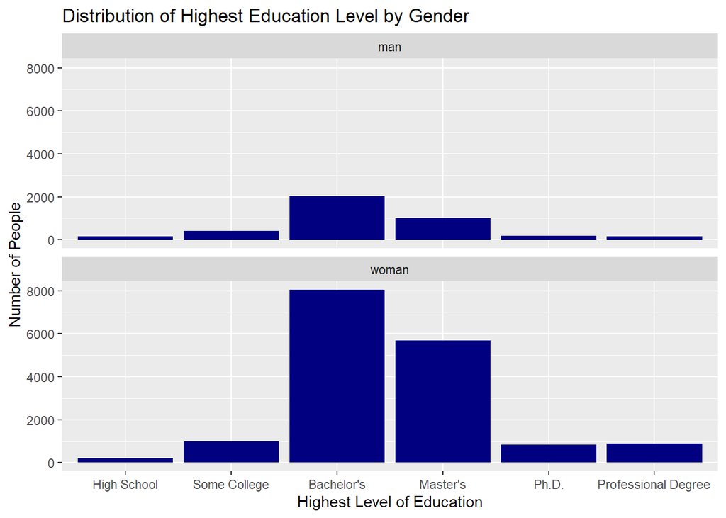

```r
# Generate bar graph
education_gender_cleaned %>%
  ggplot(aes(x = education)) +
  geom_bar(fill = "#000080") +
  facet_wrap(~gender, nrow = 2) +
  labs(title = "Distribution of Highest Education Level by Gender",
       x = "Highest Level of Education",
       y = "Number of People")
```

From this plot, it is clear that women were the majority in those who answered the survey. Because of the vast difference in number of responses, it isn’t really easy to see how the two genders compare. We introduce a normalized version of these charts in a side-by-side form to solve this. This new plot utilizes normalization via `group_by()` and `summarize()`, and gives a much better picture of the difference between the education levels.

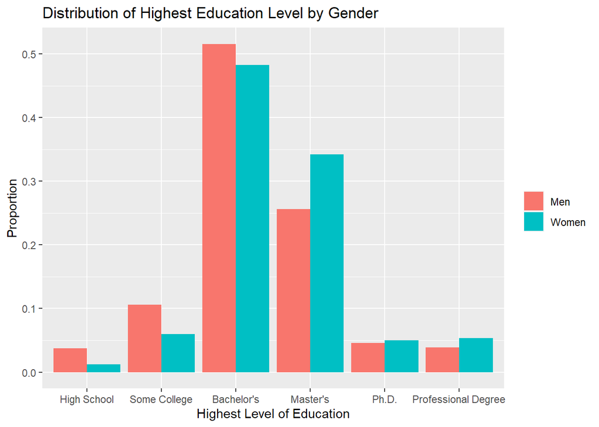

```r
# Relative
education_gender_cleaned %>%
  group_by(education) %>%
  summarize(mcnt = (sum(!is.na(education) & gender == "man")),
            wcnt = (sum(!is.na(education) & gender == "woman"))) %>%
  mutate(men = mcnt/sum(mcnt),
         women = wcnt/sum(wcnt)) %>%
  pivot_longer(cols = c("women", "men"),
               names_to = "gender",
               values_to = "proportion") %>%
  ggplot(mapping = aes(x = education,
                y = proportion,
                fill = gender)) +
  geom_bar(position = "dodge",
           stat = "identity") +
  theme(legend.title = element_blank()) +
  scale_fill_discrete(labels = c("Men", "Women")) +
  labs(title = "Distribution of Highest Education Level by Gender",
       x = "Highest Level of Education",
       y = "Proportion")
```

Now, we are going to create a histogram of annual income with both genders. There is one individual whose reported annual income is over $5 million when the median annual income is only $79,000 which heavily skews our data to the right. To fix this issue and eliminate any other values that may heavily skew the data, we are going to filter out any reported annual incomes that are over $350,000. We create a `ggplot` graph on top of it, using the density of the salaries instead of actual counts to avoid the same problem encountered with the education analysis.

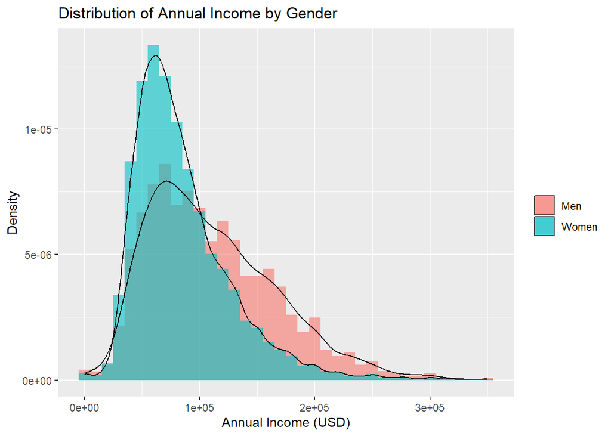

```r
education_gender_cleaned %>%
  filter(extrapolated_annual_salary_unitless <= 350000) %>%
  ggplot(aes(x = extrapolated_annual_salary_unitless)) +
  geom_histogram(aes(y = ..density..,
                     fill = gender),
                 binwidth = 10000,
                 position = "identity",
                 alpha = 0.6) +
  geom_density(aes(group = gender),
               alpha = 0.3) +
  labs(title = "Distribution of Annual Income by Gender",
       x = "Annual Income (USD)",
       y = "Density") +
  theme(legend.title = element_blank()) +
  scale_fill_discrete(labels = c("Men", "Women"))
```

# **How Does the Gender Wage Gap Vary Throughout Different States Within the U.S?**

As our previously constructed figure on men’s and women’s salaries showed, there is a difference in the distributions. Specifically, it looks like there are more men with higher salaries. We will investigate this difference with a geographical approach - we will take the average salaries for each binary gender in each U.S. state and compare them via a map visualization. To do so, we must first prepare our data for a `ggplot` map.

Because the map information given by `map_data("state")` only maps out the continental U.S., it does not include information to map out Alaska and Hawaii. Therefore, we can remove these states from our analysis. Additionally, we must deal with the entries with multiple states. These represent people who have worked in multiple states, and we do not want to double count these people, so we remove these entries altogether.

```r
numCommas <- salary_clean_country$us_state %>%
  str_replace_all("(hawaii|alaska)(,\\s)*", "") %>%
  str_detect(",") %>%
  sum()

numEmpty <- salary_clean_country$us_state %>%
  str_replace_all("(hawaii|alaska)(,\\s)*", "") %>%
  str_replace_all(",.*$", "") %>%
  str_detect("^$") %>%
  sum()

salary_clean_map <- salary_clean_country

salary_clean_map$us_state <- salary_clean_map$us_state %>%
  str_replace_all("(hawaii|alaska)(,\\s)*", "") %>%
  str_replace_all(",.*$", "")

salary_clean_map <- salary_clean_map %>%
  filter(us_state != "")

head(salary_clean_map)
```

```
##   extrapolated_annual_salary_unitless       us_state       education gender
## 1                               55000  massachusetts master's degree  woman
## 2                               34000      tennessee  college degree  woman
## 3                               62000      wisconsin  college degree  woman
## 4                               60000 south carolina  college degree  woman
## 5                               62000  new hampshire master's degree    man
## 6                               33000 south carolina  college degree  woman
```

While this method may cause us to lose some information, there are only 95 entries with multiple states after removing Hawaii and Alaska, while we have 21617 non Hawaii/Alaska entries in total, meaning that removing these entries probably will not impact our analysis too much. Furthermore, there are only 153 empty values - indicating the surveyed did not fill out a state - in our cleaned dataset to begin with, meaning we can also drop these without impacting our analysis too much.

We can now proceed to the actual creation of the map. We first define `clean_map` as a theme for our map to use. By default, `ggplot` canvases are lined with a background as well as a grid, both of which we do not need. This theme gets rid of all these extraneous elements and allows us to create a clean and concise map. We then define several functions: `getSalary()`, `makeGraph()` and `makeGraphGender()`. They do these things respectively:

- `getSalary(g)`
  - Calculates the state-average salary for the given gender `g`, and returns the result as a dataframe with 2 columns - 1 for state and 1 for the state-average salary for the given gender in that state.
- `makeGraph(d, t, l, lo, hi)`
  - Creates a `ggplot` map given the dataset `d`. It will title the graph `t` and have the legend title as `l`, with lower and upper bounds of the color scale at `lo` and `hi` respectively.
- `makeGraphGender(g)`
  - Creates the map that we want. This function incorporates `getSalary()` and `makeGraph()` to 1) create a dataframe containing both the map coordinate information as well as the salary information for the given gender `g` and 2) creates the map corresponding to that gender.

Using these functions, we plot the average salaries of the two binary genders for each state.

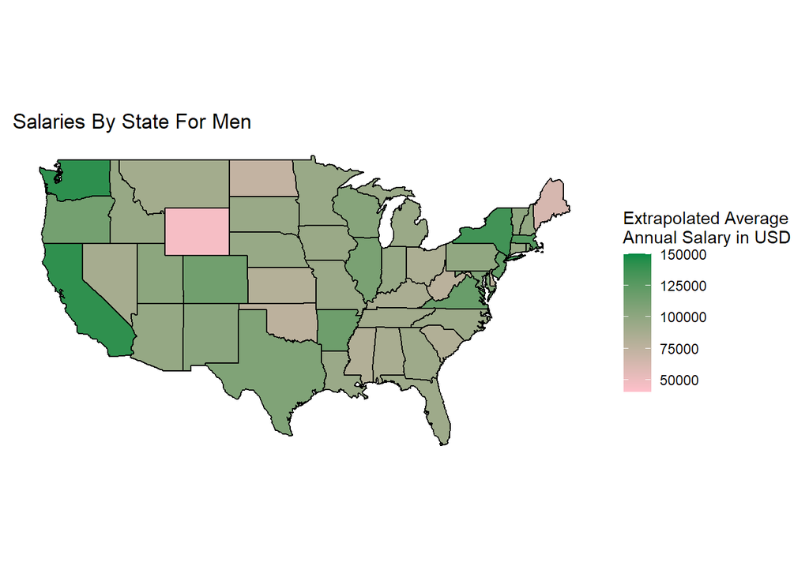

```r
# Clean map theme
clean_map <- theme(
  axis.text = element_blank(),
  axis.line = element_blank(),
  axis.ticks = element_blank(),
  panel.background = element_blank(),
  panel.border = element_blank(),
  panel.grid = element_blank(),
  axis.title = element_blank()
  )


# Function to compute state-average salaries
getSalary <- function(g){
  gendered_state_salaries <- salary_clean_map %>%
    filter(gender == g) %>%
    group_by(us_state) %>%
    summarize(salary = mean(extrapolated_annual_salary_unitless, na.rm = TRUE))

    return (gendered_state_salaries)
}


# Function for creating maps
makeGraph <- function(d, t, l, lo, hi){
ggplot(d, aes(x = long, y = lat, fill = salary)) +
    geom_polygon(aes(group = group),
                 color = "black") +
    coord_fixed(1.3) +
    scale_fill_continuous(low = "pink",
                          high = "springgreen4",
                          limits = c(lo, hi),
                          name = l) +
    clean_map +
    ggtitle(t %>% str_to_title())
}

# Function for creating maps for inputted gender g: c("man", "woman")
makeGraphGender <- function(g){
  gendered_state_salaries <- getSalary(g)

  state_map_df <- map_data("state") %>%
    left_join(gendered_state_salaries, by = c("region" = "us_state"))

  makeGraph(d = state_map_df,
            t = paste0("Salaries by State for ", str_replace(g, "a", "e")),
            l = "Extrapolated Average\nAnnual Salary in USD",
            lo = 40000,
            hi = 150000)
}


# Generate maps for men and women
plots <- map(.x = c("man", "woman"),
             .f = makeGraphGender)

plots[[1]]
```